# NTO

- Генеарция данных
  - Задача 1
  - Решение задания 1
  - Задача 2
  - Решение задания 2
- Статистический анализ
  - Задача 3
  - Решение задания 3
- Гистограммы и оценки плотности для годовой выручки и количества сотрудников
  - Задача 4
  - Решение задания 4
  - Задача 5
  - Решение задания 5
  - Задача 6
  - Решение задания 6
  - Задача 7
  - Решение задания 7
  - Задача 8
  - Решение задания 8
- Временные ряды
  - Задача 9
  - Решение задания 9
- Пространственные данные
  - Задача 10
  - Решение задания 10
  - Задача 11
  - Решение задания 11
- Интерфейсы и база данных
  - Задача 12
  - Решение задания 12
  - Задача 13
  - Решение задания 13

### Легенда:

Ученик Алексей по факту программист-аналитик, но в душе художник. И считает, что мало проанализировать, необходимо еще и представить это так, чтобы результаты анализа были наглядными и понятними всем.

Помоги Алексею создать идеальную комбинацию аналитики экономических данных и визуализации результатов. Двигайся по шагам в файле, внимательно изучай теорию, последовательно запускай код и решай задания, дописывая недостающий фрагменты.

# Генерация данных

Сложно создать идеальный пример аналитики данных без данных :) Алексей решил создать свою собственную выборку экономических данных для 1000 фирм.

Для этого Алексею понадобится (1) работать с форматом данных **csv** и (2) генератор случайных чисел и соответствуюзие библиотеки (1) **`csv`** и (2) **`random`**.

Подключи их с помощью ключевого слова `import`.

```python
import csv
import random
```

Далее нам нужен запуск генератора случайных чисел для создания выборки. Не забудь предварительно настроить функцию `random.seed()`.

**Python random.seed()**:

> Функция `random.seed()` предназначена для инициализации случайных чисел. Если передать генератору случайных чисел некое начальное число, то при запуске программы ты каждый раз будешь получать один и тот же результат. Т.е. создашь предсказуемый генератор случайных чисел.

> Для того, чтобы в этом задании все получилось как надо, перед генерацией запусти функцию с начальным значением 42 - `random.seed(42)`.

> *ВАЖНО: Обрати внимание на начальное значение, если у тебя оно будут другим, то результаты анализа данных в будущем могут не сойтись.*

```python
# Не меняйте код в этой ячейке!
# Задаем seed для воспроизводимости результатов
random.seed(42)
```

В нашей экономической выборке Алексей хочет хранить следующие сведения:

- Год основания фирмы (от 1990 до 2020).
- Годовая выручка фирмы (в диапазоне от 100,000 до 10,000,000).
- Количество сотрудников в фирме (от 10 до 500).

Данные удобно хранить в списках, которые могут быть созданы заранее. Подробнее о списках - [почитать тут](https://pythonworld.ru/tipy-dannyx-v-python/spiski-list-funkcii-i-metody-spiskov.html)

Заведи под эти сведения пустые списки.

```python
# Создаем пустые списки для данных
years = []
revenues = []
employees = []
```

Итак, генерируем случайные данные для 1000 фирм. Генерация данных осуществляется с помощью библиотеки `random` и метода `randint()`. Для добавления параметров в списки используй метод `.append()`.

### Задача №1

Допиши фрагмент кода для генерации данных годовой выручки фирмы и количества сотрудников по образцу списка `year` (год основания фирмы).

*ВАЖНО: Обрати внимание на указанные диапазоны, если у тебя они будут другие, то результаты анализа данных в будущем могут не сойтись.*

```python
# Генерируем случайные данные для 1000 фирм

for _ in range(1000):
    # Год основания фирмы (от 1990 до 2020)
    year = random.randint(1990, 2020)
    years.append(year)

    # Допиши фрагмент кода для генерации данных по образцу выше
    # Годовая выручка фирмы (в диапазоне от 100000 до 10000000)


    # Количество сотрудников в фирме (от 10 до 500)
```

### Решение

```python
%%capture
# Генерируем случайные данные для 1000 фирм
for _ in range(1000):
    # Год основания фирмы (от 1990 до 2020)
    year = random.randint(1990, 2020)
    years.append(year)

    # Годовая выручка фирмы (в диапазоне от 100,000 до 10,000,000)
    revenue = random.randint(100000, 10000000)
    revenues.append(revenue)

    # Количество сотрудников в фирме (от 10 до 500)
    employee_count = random.randint(10, 500)
    employees.append(employee_count)
```

Далее данные необходимо разместить в файле формата csv.

*CSV* (от англ. Comma-Separated Values — значения, разделённые запятыми) - это текстовый файл с "таблицей" внутри.

Каждая строчка файла - это как строчка таблицы. А значения строки по столбцам разделены запятой (или точкой с запятой для некоторых версий).

Пример CSV-файла:

```
Номер, Год, Страна
1, 2023, Россия
```

После открытия csv-файла в табличных редакторах, или после импорта его содержания в структуру данных мы увидим следующую картину:

| Номер | Год | Страна |
| --- | --- | --- |
| 1 | 2023 | Россия |

В коде ниже посмотрите, как необходимо указать названия столбцов и передать их для записи в файл. Выполните код и оцените результат.

В случае возникновения ошибки из-за несовпадений кодировок, можно заменить первую строку блока на  
`with open('economic_data.csv', 'w', newline='', encoding="utf-8") as csvfile:`

### Задача №2: сгенерированные экономический данные для 1000 фирм, сохранить в файле **csv**

### Решение

```python
# Записываем данные в CSV файл
with open('economic_data.csv', 'w', newline='') as csvfile:
    fieldnames = ['Год основания', 'Годовая выручка', 'Количество сотрудников']
    writer = csv.DictWriter(csvfile, fieldnames=fieldnames)

    writer.writeheader()
    for i in range(1000):
        writer.writerow({'Год основания': years[i], 'Годовая выручка': revenues[i], 'Количество сотрудников': employees[i]})
```

**Что проверяется в задании:** Соответвие получивашегося файла .csv с исходным Названия колонок: "Год основания", "Годовая выручка", "Количество сотрудников"

Для более удобной работы, после сохранения данных формате .csv следует преобразовать их в датафрейм используя бибилиотеку `pandas`.

*Библиотека Pandas и датафреймы*

*Pandas* — это Python-библиотека, созданная специально для отображения, анализа и обработки структурированных данных.

Название библиотеки расшифровывается как «panel data» или «панельные данные». Панельные данные - это как раз данные, представленные в виде таблиц и имеющие четкую структуру (структурированные).

У библиотеки есть официальный сайт, на котором описано, как можно начать работу с этой библиотекой - [почитать тут](https://pandas.pydata.org/getting_started.html).

*Датафреймы* (тип данных *DataFrame* из библиотеки Pandas) — это таблица со строками и столбцами, которая похожий на таблицу из приложения Excel. В это типе данных мы сможем разместить данные их нашего csv-файла и потом их обрабатывать: сортировать, группировать, производить вычисления.

Начнем работу с этой библиотекой с ее импорта в файл проекта `import pandas`.

Для более краткого обращения к библиотеке из кода проекта указываем короткое имя `pd` - `import pandas as pd`.

Прочитаем содержимое датафрейма в переменную `df`, используя функцию `pd.read_csv('economic_data.csv')`.

Обратите внимание, что для доступа к функции `pd.read_csv()` мы сначала указываем краткое имя библиотеки, а в качестве аргумента - имя csv-файла, в котором размещен датафрейм.

```python
import pandas as pd
df = pd.read_csv('economic_data.csv')
```

Проверим, что все загрузилось правильно, и выведем первые 5 записей датафрейма.

```python
df.head()
```

|  | Год основания | Годовая выручка | Количество сотрудников |
| --- | --- | --- | --- |
| 0 | 2010 | 4332413 | 437 |
| 1 | 1993 | 7990439 | 19 |
| 2 | 1990 | 9149949 | 36 |
| 3 | 2013 | 5971360 | 124 |
| 4 | 1998 | 1251225 | 409 |

Теперь давайте выведем описание прочтенных данных.

Функции, которые могут пригодиться при решении: `.describe()`

```python
df.describe()
```

|  | Год основания | Годовая выручка | Количество сотрудников |
| --- | --- | --- | --- |
| count | 1000.000000 | 1.000000e+03 | 1000.000000 |
| mean | 2005.086000 | 5.174739e+06 | 254.614000 |
| std | 8.970567 | 2.869787e+06 | 136.943625 |
| min | 1990.000000 | 1.193110e+05 | 12.000000 |
| 25% | 1997.000000 | 2.649076e+06 | 143.000000 |
| 50% | 2005.000000 | 5.348274e+06 | 252.000000 |
| 75% | 2013.000000 | 7.660033e+06 | 366.000000 |
| max | 2020.000000 | 9.995027e+06 | 500.000000 |

Рекомендуем вам так же изучить другие описательные функции для датафреймов - [почитать тут.](https://pandas.pydata.org/pandas-docs/stable/reference/frame.html#computations-descriptive-stats)

# Статистический анализ

Теперь у тебя есть данные - можно приступать к их анализу.

Ученик Андрей спланировал

- Рассчитайте средние значения и медианы для каждой переменной.
- Постройте гистограммы и оценки плотности для годовой выручки и количества сотрудников.
- Вычислите корреляции между годом основания и годовой выручкой фирмы.
- Выявите фирмы, которые считаются стартапами (фирмы, основанные после 2010 года, с выручкой менее 1,000,000 и менее чем 50 сотрудниками) и определите их процентное соотношение от общего числа фирм.

### Cредние значения и медианы

Как считается среднее значение

[figure not shown]

Как считается медиана

[figure not shown]

> Медиана — это значение, которое разделяет упорядоченный набор данных на две равные половины. Для расчета медианы в упорядоченном наборе данных, количество элементов которого нечетное, медиана - это значение, которое находится в середине упорядоченного списка. Если количество элементов четное, медиана - это среднее арифметическое двух центральных значений. Для набора данных X длиной n, где n - нечетное число, медиана M рассчитывается следующим образом:

Если n нечетное:

$$ M = X * (n+1)/2 $$

Если n четное:

$$ M = (X * n/2 + X(n/2 +1))/2 $$

Здесь X(i) представляет собой i-е значение в упорядоченном наборе данных X.

**Пожалуйста, обратите внимание, что перед вычислением медианы набор данных обычно сортируется по возрастанию или убыванию.**

### Задача №3: Расчитайте среднее значение и медианное для всех колонок

### Решение

```python
# Расчет среднего значения для каждой переменной
average_year = df['Год основания'].mean()
average_revenue = df['Годовая выручка'].mean()
average_employees = df['Количество сотрудников'].mean()
```

```python
median_year = df['Год основания'].median()
median_revenue = df['Годовая выручка'].median()
median_employees = df['Количество сотрудников'].median()
```

```python
print(round(average_year,2), round(average_revenue,2), round(average_employees,2) )
print(round(median_year,2), round(median_revenue,2), round(median_employees,2) )
```

```
2005.09 5174738.95 254.61
2005.0 5348274.5 252.0
```

# Гистограммы и оценки плотности для годовой выручки и количества сотрудников

Две основные бибилотеки для построения диаграмм это matplotlib и seaborn.

Сначала необходимо их подключть.

```python
import matplotlib.pyplot as plt
import seaborn as sns
```

Для построения линейного графика по точкам используется функция plot():

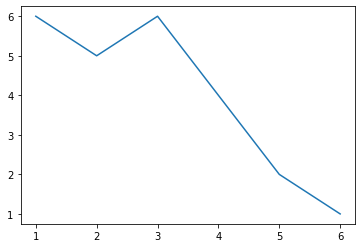

```python
plt.plot(
    [1, 2, 3, 4, 5, 6],      # X координаты.
    [6, 5, 6, 4, 2, 1]       # Y координаты.
)

plt.show()                   # Показать график.
```

> Для отрисовки нескольких линий на одном графике нужно просто использовать несколько функций **`plot()`**:

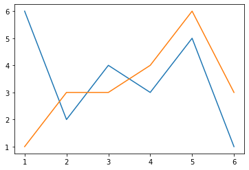

```python
plt.plot(
    [1, 2, 3, 4, 5, 6],
    [6, 2, 4, 3, 5, 1]
)

plt.plot(
    [1, 2, 3, 4, 5, 6],
    [1, 3, 3, 4, 6, 3]
)

plt.show()
```

> В matplotlib возможно настроить внешний вид графика с помощью параметров:

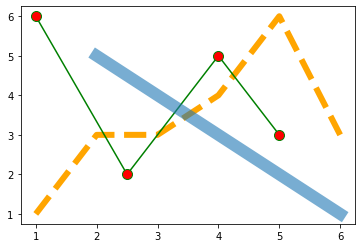

```python
plt.plot(
    [1, 2, 3, 4, 5, 6],
    [1, 3, 3, 4, 6, 3],
    linewidth = 6,               # Толщина линии.
    color = 'orange',            # Цвет линии
    linestyle = '--'             # Тип линии: '-', '--', '-.', ':', ''.
)

plt.plot(
    [1, 2.5, 4, 5],
    [6, 2, 5, 3],
    color = 'green',
    marker = 'o',                # Тип маркера
    markersize = 10,             # Размер маркера.
    markerfacecolor = 'red'      # Цвет маркера.
)

plt.plot(
    [2, 6],
    [5, 1],
    linewidth = 12,
    alpha = 0.6                  #  Степень непрозрачности линии
)                                #  от 0  до 1 .

plt.show()
```

> bar используется для построения столбчатой диаграммы:

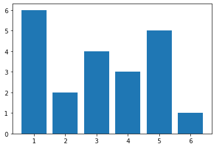

```python
plt.bar(
    [1, 2, 3, 4, 5, 6],      # X координаты центров столбцов.
    [6, 2, 4, 3, 5, 1]       # Высота столбцов.
)

plt.show()
```

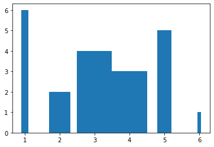

```python
plt.bar(
    [1, 2, 3, 4, 5, 6],
    [6, 2, 4, 3, 5, 1],
    width = [0.2, 0.6, 1, 1, 0.4, 0.1]      # Ширина (толщина) столбцов от 0 до 1 (по умолчанию = 0.8).
)                                           # Если все столбцы одинаковой ширины, можно написать просто одно число.

plt.show()
```

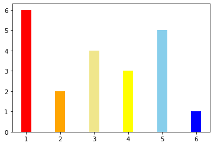

```python
plt.bar(
    [1, 2, 3, 4, 5, 6],
    [6, 2, 4, 3, 5, 1],
    width = 0.3,
    color = [                # Список названий цветов, либо название
        'red',               # одного цвета, если все одинаковые.
        'orange',
        'khaki',
        'yellow',
        'skyblue',
        'blue'
    ]
)

plt.show()
```

### Задача №4. Гистограмма и оценка плотности для годовой выручки

Постройте гистограимму оценки плотности для годовой выручки и оценки плотности для количества сотрудников

### Решение

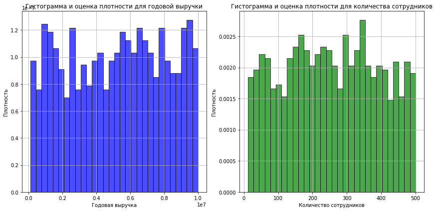

```python
plt.figure(figsize=(12, 6))

# Гистограмма и оценка плотности для годовой выручки
plt.subplot(1, 2, 1)
plt.hist(df['Годовая выручка'], bins=30, alpha=0.7, color='blue', edgecolor='black', density=True)
plt.title('Гистограмма и оценка плотности для годовой выручки')
plt.xlabel('Годовая выручка')
plt.ylabel('Плотность')
plt.grid(True)

# Гистограмма и оценка плотности для количества сотрудников
plt.subplot(1, 2, 2)
plt.hist(df['Количество сотрудников'], bins=30, alpha=0.7, color='green', edgecolor='black', density=True)
plt.title('Гистограмма и оценка плотности для количества сотрудников')
plt.xlabel('Количество сотрудников')
plt.ylabel('Плотность')
plt.grid(True)

# Отображение графиков
plt.tight_layout()
plt.show()
```

#### Построение графика seaborn

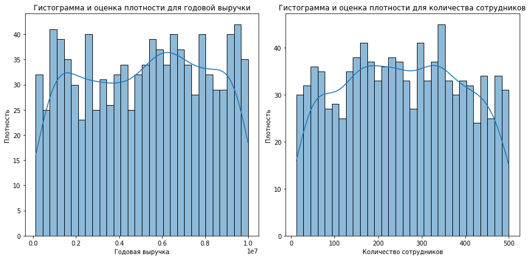

```python
plt.figure(figsize=(12, 6))
plt.subplot(1, 2, 1)
sns.histplot(df['Годовая выручка'], kde=True, bins=30)
plt.title('Гистограмма и оценка плотности для годовой выручки')
plt.xlabel('Годовая выручка')
plt.ylabel('Плотность')

# Построение гистограммы и оценки плотности для количества сотрудников
plt.subplot(1, 2, 2)
sns.histplot(df['Количество сотрудников'], kde=True, bins=30)
plt.title('Гистограмма и оценка плотности для количества сотрудников')
plt.xlabel('Количество сотрудников')
plt.ylabel('Плотность')

# Отображение графиков
plt.tight_layout()
plt.show()
```

**Что проверяется в задании:** Визуальное сравнение диаграмм

### Корреляции между годом основания и годовой выручкой фирмы.

*Корреляция - это способ изучать, как величины изменяются вместе. Если две величины коррелируют, это означает, что, когда одна из них меняется, другая тоже меняется, но это не обязательно значит, что одна из них вызывает изменения в другой.*

### Задача №5. Расчитайте значение корреляции между полями 'Год основания' и 'Годовая выручка'

### Решение

```python
correlation = df['Год основания'].corr(df['Годовая выручка'])
```

```python
correlation
```

```
0.015684354966626377
```

**Что проверяется в задании:** Соответвие вывода, без округления: 0.015684354966626377

Если вы вывести в значения корреляции в графическом формате можно использовать код ниже

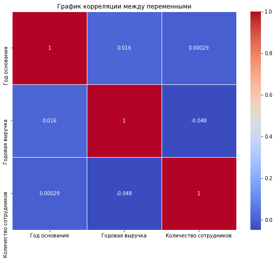

```python
correlation_matrix = df.corr()


plt.figure(figsize=(10, 8))
sns.heatmap(data=correlation_matrix, annot=True, cmap='coolwarm', linewidths=.5)
plt.title('График корреляции между переменными')
plt.show()
```

### Задача №6. Найдите количество стартапов в наборе данных

Стартап - это организации, соответвующие параметрам:

[output not shown]

Требутся расчитать следущие показатели:

```
- всего фирм
- кол-во стартапов
- процент стартапов от всех фирм
```

### Решение

```python
startups = df[(df['Год основания'] > 2010) & (df['Годовая выручка'] < 1000000) & (df['Количество сотрудников'] < 50)]

total_firms = len(df)
startup_firms = len(startups)
percentage_startups = (startup_firms / total_firms) * 100

print(total_firms, startup_firms,percentage_startups )
```

```
1000 1 0.1
```

**Что проверяется в задании:** Соответвие вывода, без округления: 1000 1 0.1

Опишите основные характеристики выборки и найденные статистические закономерности.

### Задача №7. Каково среднее время существования фирм в выборке?

```python
current_year = 2023
```

### Решение

```python
df['Время существования'] = current_year - df['Год основания']
average_lifetime = df['Время существования'].mean()
print(average_lifetime)
```

```
17.914
```

**Что проверяется в задании:** Соответвие вывода, без округления: 17.914

### Задача №8. Существует ли связь между годом основания и годовой выручкой?

Посчитатйте корреляцию

### Решение

```python
correlation = df['Год основания'].corr(df['Годовая выручка'])
print(correlation)
```

```
0.015684354966626377
```

**Что проверяется в задании:** Соответвие вывода, без округления: 0.015684354966626377

# Временные ряды

*Временной ряд - это последовательность данных, измеренных в разные моменты времени. Эти данные обычно упорядочены в хронологическом порядке, что означает, что каждое измерение связано с определенным моментом времени. Временные ряды широко используются для анализа и прогнозирования различных явлений, которые меняются с течением времени.*

### Загрузите данные из датасета.

```python
import pandas as pd

url = "https://raw.githubusercontent.com/jbrownlee/Datasets/master/daily-min-temperatures.csv"
df = pd.read_csv(url)
df.head()
```

|  | Date | Temp |
| --- | --- | --- |
| 0 | 1981-01-01 | 20.7 |
| 1 | 1981-01-02 | 17.9 |
| 2 | 1981-01-03 | 18.8 |
| 3 | 1981-01-04 | 14.6 |
| 4 | 1981-01-05 | 15.8 |

### Задача №9. Постройте визуализацию зависимости температуры от дня.

### Решение

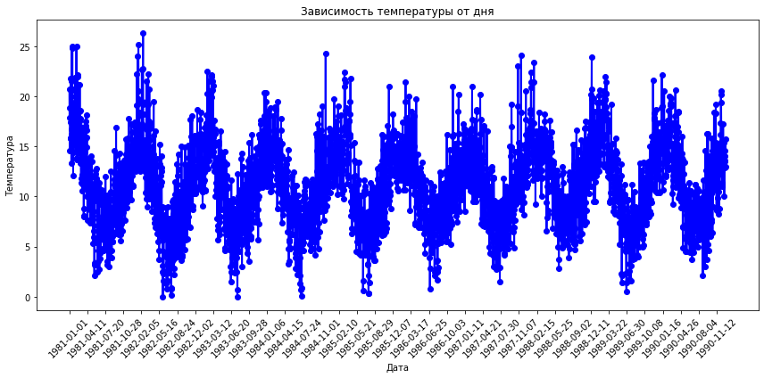

```python
plt.figure(figsize=(12, 6))
plt.plot(df['Date'], df['Temp'], color='blue', marker='o', linestyle='-', linewidth=2, markersize=6)
plt.title('Зависимость температуры от дня')
plt.xlabel('Дата')
plt.ylabel('Температура')
plt.xticks(df['Date'][::100], rotation=45)  # Отображаем каждую сотую дату для улучшения читаемости
plt.tight_layout()
plt.show()
```

**Что проверяется в задании:** Соответвие вида графика

Так же можно, к примеру, выделить сезонные паттерны в данных. Определите, когда в году обычно бывает холодно, а когда тепло. Можно использовать средние значения температур по месяцам.

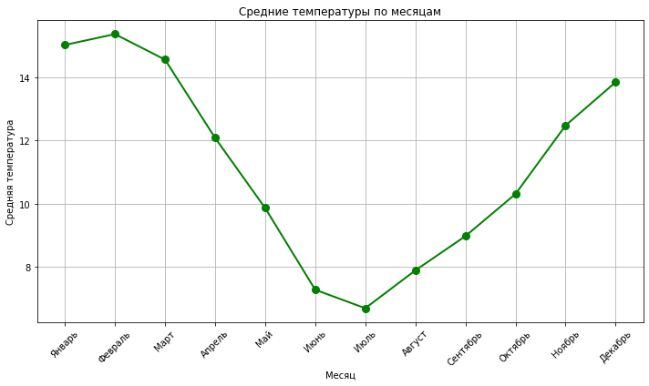

```python
df['Date'] = pd.to_datetime(df['Date'])

df['Month'] = df['Date'].dt.month

average_temperatures = df.groupby('Month')['Temp'].mean()

# Месяцы в году
months = ['Январь', 'Февраль', 'Март', 'Апрель', 'Май', 'Июнь', 'Июль', 'Август', 'Сентябрь', 'Октябрь', 'Ноябрь', 'Декабрь']

# Построение визуализации средних температур по месяцам
plt.figure(figsize=(10, 6))
plt.plot(months, average_temperatures, marker='o', color='green', linestyle='-', linewidth=2, markersize=8)
plt.title('Средние температуры по месяцам')
plt.xlabel('Месяц')
plt.ylabel('Средняя температура')
plt.grid(True)
plt.xticks(rotation=45)
plt.tight_layout()
plt.show()
```

# Пространственные данные

1. Скачать датасет со стационарными местами торговли в формате JSON https://data.mos.ru/datasets/3304
2. Переименовать в 'moscow_data.json'

*JSON - это способ организации данных, который используется в компьютерных программах. Это аббревиатура, которая расшифровывается как "JavaScript Object Notation" (Нотация объектов JavaScript), но не обязательно связана только с языком программирования JavaScript.*

*Представьте JSON как способ записи информации, похожий на список с данными. Этот список состоит из пар "ключ" и "значение". Ключ - это слово или фраза, которое описывает, что находится в значении. Значение - это собственно информация.*

```python
moscow_shops_path='data/moscow_data.json'
```

```python
import json
with open(moscow_shops_path, encoding = 'cp1251') as file:
    data = json.load(file)
```

Преобразуем данные в датафрейм

```python
import pandas as pd

df = pd.DataFrame(data)
df.head()
```

|  | global_id | ID | Name | IsNetObject | OperatingCompany | TypeService | TypeObject | AdmArea | District | Address | PublicPhone | WorkingHours | ClarificationOfWorkingHours | geoData |
| --- | --- | --- | --- | --- | --- | --- | --- | --- | --- | --- | --- | --- | --- | --- |
| 0 | 637390942 | 000069305 | Одежда. Обувь. Промтовары | нет |  | реализация непродовольственных товаров | Магазин «Промтовары» | Северный административный округ | район Беговой | город Москва, Беговая аллея, дом 3А | [{'PublicPhone': '(977) 757-40-37'}] | [{'DayOfWeek': 'понедельник', 'Hours': '09:30-... |  | {'coordinates': [37.564782, 55.7833609999999],... |
| 1 | 637391109 | 000069320 | АЙКОВЕР | нет |  | реализация непродовольственных товаров | Магазин-салон | Центральный административный округ | Тверской район | город Москва, Новослободская улица, дом 50/1, ... | [{'PublicPhone': '(499) 250-12-40'}] | [{'DayOfWeek': 'понедельник', 'Hours': '10:00-... |  | {'coordinates': [37.5948494823958, 55.78655886... |
| 2 | 637391714 | 000069342 | Точка любви | да | Точка любви | реализация непродовольственных товаров | Прочие специализированные непродовольственные ... | Северный административный округ | район Беговой | город Москва, Ленинградский проспект, дом 12 | [{'PublicPhone': '(925) 659-93-01'}] | [{'DayOfWeek': 'понедельник', 'Hours': '10:00-... |  | {'coordinates': [37.5787834986412, 55.78018806... |
| 3 | 637392270 | 000069357 | Магазин Выпечка, пекарня | нет |  | реализация продовольственных товаров | Магазин «Продукты» | Южный административный округ | Даниловский район | город Москва, улица Даниловский Вал, дом 10 | [{'PublicPhone': '(499) 765-78-23'}] | [{'DayOfWeek': 'понедельник', 'Hours': '08:00-... |  | {'coordinates': [37.6251772588661, 55.71120059... |
| 4 | 637392326 | 000069362 | Togas | да | Togas | реализация непродовольственных товаров | Магазин «Ткани» | Западный административный округ | район Раменки | город Москва, Мичуринский проспект, дом 22, ко... | [{'PublicPhone': '(495) 932-98-56'}] | [{'DayOfWeek': 'понедельник', 'Hours': '10:00-... |  | {'coordinates': [37.503886, 55.7012649999999],... |

### Задача №10. Подготовить данные для расчета метрик

1. Использовать регулярные выражения и выделить только слова
2. Перевести текст в нижний регистр (строчные буквы)

*Регулярные выражения - это специальные шаблоны или правила для поиска и обработки текста в компьютерных программах. Они позволяют находить определенные части текста или проверять, соответствует ли текст определенному формату.*

### Решение

```python
import re

names = list(df['Name'])

p_txt = ' '.join(names)
pattern = "[^а-яА-Яa-zA-Z ]"
p_txt = re.sub(pattern, ' ', p_txt)
p_txt = p_txt.lower()
```

**Что проверяется в задании:** Соответвие вывода, переменная ```p_txt```

Расчитываем метрику при помощи библиотеки

```python
from sklearn.feature_extraction.text import TfidfVectorizer
corpus = [p_txt]
vectorizer = TfidfVectorizer()
X = vectorizer.fit_transform(corpus)
X = X.todense()
voc = vectorizer.get_feature_names_out()
words = []
tf_idf = []
for i in range(len(voc)):
    words.append(voc[i])
    tf_idf.append(X[0,i])
df2 = pd.DataFrame({'word':words, 'tf-idf': tf_idf})
df2 = df2.sort_values(by = ['tf-idf'],ascending = False) #сортируем по убыванию
df2
```

|  | word | tf-idf |
| --- | --- | --- |
| 10274 | магазин | 0.542803 |
| 12299 | продукты | 0.369241 |
| 11352 | одежда | 0.321492 |
| 13734 | табак | 0.255268 |
| 14741 | цветы | 0.211422 |
| ... | ... | ... |
| 6727 | асессуары | 0.000130 |
| 6728 | асколи | 0.000130 |
| 6729 | аскона | 0.000130 |
| 6730 | аслан | 0.000130 |
| 15392 | ячмень | 0.000130 |

15393 rows × 2 columns

### Задача №11. Выделить топ 5 важных слов

### Решение

```python
words = list(df2['word'])
important_words = words[:5]
important_words
```

```
['магазин', 'продукты', 'одежда', 'табак', 'цветы']
```

**Что проверяется в задании:** Соответвие вывода ```['магазин', 'продукты', 'одежда', 'табак', 'цветы']```

# Интерфейсы и база данных

Для визуализации данных удобно сохранить все данные в базе данных (к примеру, sqllite)

```python
import pandas as pd

url = "https://raw.githubusercontent.com/jbrownlee/Datasets/master/daily-min-temperatures.csv"
df = pd.read_csv(url)
```

```python
from sqlite3 import connect
```

```python
conn = connect('data.db')
```

```python
df.head()
```

|  | Date | Temp |
| --- | --- | --- |
| 0 | 1981-01-01 | 20.7 |
| 1 | 1981-01-02 | 17.9 |
| 2 | 1981-01-03 | 18.8 |
| 3 | 1981-01-04 | 14.6 |
| 4 | 1981-01-05 | 15.8 |

### Задача №12. Сохранить таблицу в базе данных

Сохранить данные о погоде в таблицу `weater` базы данных sqlite

Для удобства работы можно выделить только дату из поля `date_only`

```python
df['date_only'] = pd.to_datetime(df['Date'])
```

### Решение

```python
df.to_sql('weather', conn, index=False)
```

```
3650
```

**Что проверяется в задании:** Соответвие вывода запроса из базы данных ```SELECT * FROM weather ```

Проверяем корректность работы

```python
query = '''
	SELECT * FROM weather
'''
```

```python
df_sql = pd.read_sql(query, conn)
df_sql
```

|  | Date | Temp | date_only |
| --- | --- | --- | --- |
| 0 | 1981-01-01 | 20.7 | 1981-01-01 00:00:00 |
| 1 | 1981-01-02 | 17.9 | 1981-01-02 00:00:00 |
| 2 | 1981-01-03 | 18.8 | 1981-01-03 00:00:00 |
| 3 | 1981-01-04 | 14.6 | 1981-01-04 00:00:00 |
| 4 | 1981-01-05 | 15.8 | 1981-01-05 00:00:00 |
| ... | ... | ... | ... |
| 3645 | 1990-12-27 | 14.0 | 1990-12-27 00:00:00 |
| 3646 | 1990-12-28 | 13.6 | 1990-12-28 00:00:00 |
| 3647 | 1990-12-29 | 13.5 | 1990-12-29 00:00:00 |
| 3648 | 1990-12-30 | 15.7 | 1990-12-30 00:00:00 |
| 3649 | 1990-12-31 | 13.0 | 1990-12-31 00:00:00 |

3650 rows × 3 columns

### Задача №13. Реализации интерфейса для пользователя

В этой задаче вам потребуются бибоиотеки `ipywidgets` и `IPython.display`

```python
import ipywidgets as widgets
from IPython.display import display, clear_output
```

Так же нужна будет функция для выбора данных по дате

```python
cursor = conn.cursor()
def get_weather_info(date):
    query = f"SELECT Temp FROM weather WHERE date_only = '{date}'"
    result = cursor.execute(query).fetchall()
    if result:
        return result[0][0]
    return "No data"
```

Ваша задача, используя бибилиотеку `ipywidgets` нарисовать интерфейс, который показан на рисунке

[figure not shown]

### Решение

```python
# Create a date picker widget
date_picker = widgets.DatePicker(
    description='Выберите дату',
    disabled=False
)

# Create a button widget
button = widgets.Button(description="Узнать погоду")

# Create an output widget to display the weather information
output = widgets.Output()

# Define a function to handle button click event
def on_button_click(b):
    with output:
        clear_output(wait=True)  # Clear the previous output
        selected_date = date_picker.value.strftime('%Y-%m-%d')
        weather_data = get_weather_info(selected_date)
        print(weather_data)

# Attach the button click event to the function
button.on_click(on_button_click)

# Display the widgets
display(date_picker, button, output)
```

**Что проверяется в задании:** Визуально работа интерфеса.